# Lecture 1: Introduction

## Stat598z: Introduction to computing for statistics

## Vinayak Rao

### Department of Statistics, Purdue University

# Logistics

- **Class** Tue/Thu 900-1015, Recitation Building 303
- **Class email** purduestat598z@gmail.com
- **Website** http://www.stat.purdue.edu/~varao/teach.html
- **Piazza** https://piazza.com/class/ij5v1sa8q1t5ot
- **Instructor** Vinayak Rao
  - If you email me, include STAT598 in the subject
  - E.g. ‘STAT598: My dog ate my homework’
- **Office** Math236
- **Office Hours** 1030 - 1100 Tuesdays or by appointment
- **TA** Mohit Dayal
- **Office Hours** 1200-1300 Thursdays

## Comp. statistics vs stat. computing

[*Computational statistics or statistical computing, is that the question?*, Lauro, C. , Comp Stat and Data Analysis 23 (1996)](http://econpapers.repec.org/article/eeecsdana/v_3a23_3ay_3a1996_3ai_3a1_3ap_3a191-193.htm)

**Statistical Computing**: Application of Comp. Sci. to Statistics

- Tools: programming, software, data structures and their manipulation, hardware (GPUs, parallel architectures)
- E.g. Releasing software to the world?

**Computational statistics**: Design of algorithms for implementing statistical methods on computers

- Statistical methodology
- E.g. writing a paper for a statistics journal?

This course: more of former

STAT545: more of the latter

## Goals of the course

Broadly: to learn programming for statistics

- No programming background required.
- Perhaps not the best class for those already good at this

Our focus will be on

- the R programming language
- *statistical* rather than *general-purpose* computing
- R for reproducible research rather than ad hoc analysis

## Topics covered (tentative)

- R fundamentals (data-structures, commands, flow control)
- R packages
- R plotting ( ggplot2 )
- Debugging with R
- Writing efficient R code
- R Markdown and dynamic documents
- Object-oriented programming
- Functional programming

Advanced topics (depending on how things progress):

- Introduction to C -programming, and its R interface
- Introduction to R internals
- Programming with Stan

## Textbooks

*“The Art of R Programming: A Tour of Statistical Software Design”*, Norman Matloff

Also useful:

- *“Software for Data Analysis”*, John M. Chambers
- *“An Introduction to R”* ( http://cran.r-project.org/manuals.html )
- *“Advanced R”*, Hadley Wickham

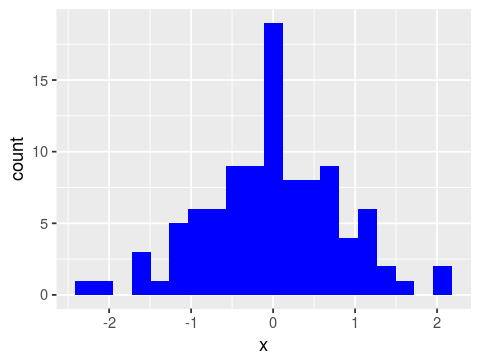

```r
library(ggplot2)
options(repr.plot.width=4, repr.plot.height=3)
ggplot(data.frame(x=rnorm(100))) + geom_histogram(aes(x=x),bins=20,
                                                 fill='blue')
```

ggplot!

```r
3+8
```

11